# Project: Patients No-show Analysis

- Introduction
- Data Wrangling
- Exploratory Data Analysis
- Conclusions

## Introduction

In this analysis we are trying to analyse the factors behind why patients do not show for appointments. The dataset "noshowappointments" collects information from 100k medical appointments in Brazil and is focused on the question of whether or not patients show up for their appointment.

```python
import pandas as pd
import numpy as np
import matplotlib.pyplot as plt
import seaborn as sns
%matplotlib inline
```

## Data Wrangling

> In this section, we have loaded in the data, check for cleanliness, making the dataset ready for analysis.

### General Properties

```python
df = pd.read_csv('noshowappointments-kagglev2-may-2016.csv')
```

```python
df.head()
```

|  | PatientId | AppointmentID | Gender | ScheduledDay | AppointmentDay | Age | Neighbourhood | Scholarship | Hipertension | Diabetes | Alcoholism | Handcap | SMS_received | No-show |
| --- | --- | --- | --- | --- | --- | --- | --- | --- | --- | --- | --- | --- | --- | --- |
| 0 | 2.987250e+13 | 5642903 | F | 2016-04-29T18:38:08Z | 2016-04-29T00:00:00Z | 62 | JARDIM DA PENHA | 0 | 1 | 0 | 0 | 0 | 0 | No |
| 1 | 5.589978e+14 | 5642503 | M | 2016-04-29T16:08:27Z | 2016-04-29T00:00:00Z | 56 | JARDIM DA PENHA | 0 | 0 | 0 | 0 | 0 | 0 | No |
| 2 | 4.262962e+12 | 5642549 | F | 2016-04-29T16:19:04Z | 2016-04-29T00:00:00Z | 62 | MATA DA PRAIA | 0 | 0 | 0 | 0 | 0 | 0 | No |
| 3 | 8.679512e+11 | 5642828 | F | 2016-04-29T17:29:31Z | 2016-04-29T00:00:00Z | 8 | PONTAL DE CAMBURI | 0 | 0 | 0 | 0 | 0 | 0 | No |
| 4 | 8.841186e+12 | 5642494 | F | 2016-04-29T16:07:23Z | 2016-04-29T00:00:00Z | 56 | JARDIM DA PENHA | 0 | 1 | 1 | 0 | 0 | 0 | No |

A number of characteristics about the patient are included in each row. PatientID and AppointmentID are unique identifiers related to individual patients and can be ignored for our analysis. WE have Gender and Age information which can play very important role in our analysis. ‘ScheduledDay’ tells us on what day the patient set up their appointment. ‘Neighborhood’ indicates the location of the hospital. ‘Scholarship’ indicates whether or not the patient is enrolled in Brasilian welfare program Bolsa Família. The last column No-show says ‘No’ if the patient showed up to their appointment, and ‘Yes’ if they did not show up

```python
df.shape
```

```
(110527, 14)
```

There are 14 columns (variables) and 110527 rows (observations)

```python
df.info()
```

```
<class 'pandas.core.frame.DataFrame'>
RangeIndex: 110527 entries, 0 to 110526
Data columns (total 14 columns):
PatientId         110527 non-null float64
AppointmentID     110527 non-null int64
Gender            110527 non-null object
ScheduledDay      110527 non-null object
AppointmentDay    110527 non-null object
Age               110527 non-null int64
Neighbourhood     110527 non-null object
Scholarship       110527 non-null int64
Hipertension      110527 non-null int64
Diabetes          110527 non-null int64
Alcoholism        110527 non-null int64
Handcap           110527 non-null int64
SMS_received      110527 non-null int64
No-show           110527 non-null object
dtypes: float64(1), int64(8), object(5)
memory usage: 11.8+ MB
```

There are no null observations here. However we see that the ScheduledDay and AppointmentDay datatypes are objects and can be changed to datetime

```python
df['ScheduledDay']=pd.to_datetime(df['ScheduledDay'])
df['AppointmentDay']=pd.to_datetime(df['AppointmentDay'])
```

```python
df.info()
```

```
<class 'pandas.core.frame.DataFrame'>
RangeIndex: 110527 entries, 0 to 110526
Data columns (total 14 columns):
PatientId         110527 non-null float64
AppointmentID     110527 non-null int64
Gender            110527 non-null object
ScheduledDay      110527 non-null datetime64[ns]
AppointmentDay    110527 non-null datetime64[ns]
Age               110527 non-null int64
Neighbourhood     110527 non-null object
Scholarship       110527 non-null int64
Hipertension      110527 non-null int64
Diabetes          110527 non-null int64
Alcoholism        110527 non-null int64
Handcap           110527 non-null int64
SMS_received      110527 non-null int64
No-show           110527 non-null object
dtypes: datetime64[ns](2), float64(1), int64(8), object(3)
memory usage: 11.8+ MB
```

ScheduledDay and AppointmentDay datatypes are now datetime

```python
df.describe()
```

|  | PatientId | AppointmentID | Age | Scholarship | Hipertension | Diabetes | Alcoholism | Handcap | SMS_received |
| --- | --- | --- | --- | --- | --- | --- | --- | --- | --- |
| count | 1.105270e+05 | 1.105270e+05 | 110527.000000 | 110527.000000 | 110527.000000 | 110527.000000 | 110527.000000 | 110527.000000 | 110527.000000 |
| mean | 1.474963e+14 | 5.675305e+06 | 37.088874 | 0.098266 | 0.197246 | 0.071865 | 0.030400 | 0.022248 | 0.321026 |
| std | 2.560949e+14 | 7.129575e+04 | 23.110205 | 0.297675 | 0.397921 | 0.258265 | 0.171686 | 0.161543 | 0.466873 |
| min | 3.921784e+04 | 5.030230e+06 | -1.000000 | 0.000000 | 0.000000 | 0.000000 | 0.000000 | 0.000000 | 0.000000 |
| 25% | 4.172614e+12 | 5.640286e+06 | 18.000000 | 0.000000 | 0.000000 | 0.000000 | 0.000000 | 0.000000 | 0.000000 |
| 50% | 3.173184e+13 | 5.680573e+06 | 37.000000 | 0.000000 | 0.000000 | 0.000000 | 0.000000 | 0.000000 | 0.000000 |
| 75% | 9.439172e+13 | 5.725524e+06 | 55.000000 | 0.000000 | 0.000000 | 0.000000 | 0.000000 | 0.000000 | 1.000000 |
| max | 9.999816e+14 | 5.790484e+06 | 115.000000 | 1.000000 | 1.000000 | 1.000000 | 1.000000 | 4.000000 | 1.000000 |

we see that the mean age of the patient is 37. More than 75% of the patients do not have Scholarship, and do not suffer from Hypertension, Diabetes, Alcoholism and Handcap.

```python
df.drop(['PatientId', 'AppointmentID'], axis=1, inplace=True)
```

We are dropping PatientId , AppointmentId as this is specific to the patient and we dont need for our analysis

```python
df.head()
```

|  | Gender | ScheduledDay | AppointmentDay | Age | Neighbourhood | Scholarship | Hipertension | Diabetes | Alcoholism | Handcap | SMS_received | No-show |
| --- | --- | --- | --- | --- | --- | --- | --- | --- | --- | --- | --- | --- |
| 0 | F | 2016-04-29 18:38:08 | 2016-04-29 | 62 | JARDIM DA PENHA | 0 | 1 | 0 | 0 | 0 | 0 | No |
| 1 | M | 2016-04-29 16:08:27 | 2016-04-29 | 56 | JARDIM DA PENHA | 0 | 0 | 0 | 0 | 0 | 0 | No |
| 2 | F | 2016-04-29 16:19:04 | 2016-04-29 | 62 | MATA DA PRAIA | 0 | 0 | 0 | 0 | 0 | 0 | No |
| 3 | F | 2016-04-29 17:29:31 | 2016-04-29 | 8 | PONTAL DE CAMBURI | 0 | 0 | 0 | 0 | 0 | 0 | No |
| 4 | F | 2016-04-29 16:07:23 | 2016-04-29 | 56 | JARDIM DA PENHA | 0 | 1 | 1 | 0 | 0 | 0 | No |

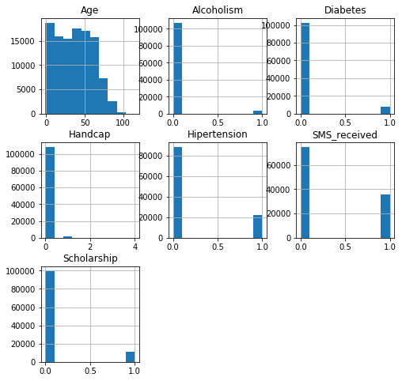

```python
df.hist(figsize = (8,8));
```

### Exploring Data

```python
df_noshow=df[df['No-show']=="Yes"]
df_show=df[df['No-show']=="No"]
```

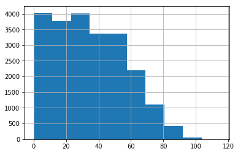

```python
df_noshow['Age'].hist();
```

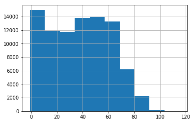

```python
df_show['Age'].hist();
```

Though there is a huge difference in the number of no-shows and show in Age, we can observe that the no-show is mostly in the age of 20-35 where as show is more towarrds 35-60. We can also see that from mean number of shows and no-shows calculated which is 34 for no-shows and 37 for shows.

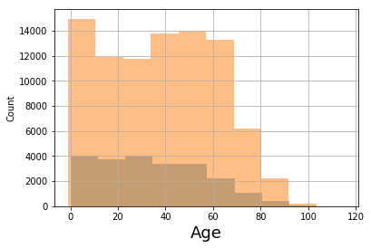

```python
df_noshow['Age'].hist(alpha=0.5,label= 'No Show')
df_show['Age'].hist(alpha=0.5, label='Show')
plt.xlabel('Age', fontsize=18);
plt.ylabel('Count')
```

```python
df.groupby('No-show')['Age'].mean()
```

```
No-show
No     37.790064
Yes    34.317667
Name: Age, dtype: float64
```

```python
df.groupby(['No-show','Gender']).count()
```

| No-show | Gender | ScheduledDay | AppointmentDay | Age | Neighbourhood | Scholarship | Hipertension | Diabetes | Alcoholism | Handcap | SMS_received |
| --- | --- | --- | --- | --- | --- | --- | --- | --- | --- | --- | --- |
| No | F | 57246 | 57246 | 57246 | 57246 | 57246 | 57246 | 57246 | 57246 | 57246 | 57246 |
|  | M | 30962 | 30962 | 30962 | 30962 | 30962 | 30962 | 30962 | 30962 | 30962 | 30962 |
| Yes | F | 14594 | 14594 | 14594 | 14594 | 14594 | 14594 | 14594 | 14594 | 14594 | 14594 |
|  | M | 7725 | 7725 | 7725 | 7725 | 7725 | 7725 | 7725 | 7725 | 7725 | 7725 |

```python
df_f=df[df['Gender']=='F']
df_m=df[df['Gender']=='M']
df_f_noshow=df_f[df_f['No-show']=='Yes']
df_f_Show=df_f[df_f['No-show']=='No']
df_m_noshow=df_m[df_m['No-show']=='Yes']
df_m_show=df_m[df_m['No-show']=='No']
female_noshow_count= df_f_noshow.count()['Gender']
male_noshow_count= df_m_noshow.count()['Gender']
female_total_count= df_f.count()['Gender']
male_total_count=df_m.count()['No-show']
```

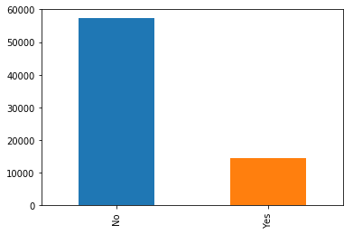

```python
df_f['No-show'].value_counts().plot(kind='bar');
```

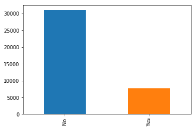

```python
df_m['No-show'].value_counts().plot(kind='bar');
```

In the above formulae we are first dividing Gender into two groups male and female and further dividing it into groups show and no-show. We are then calculating number of shows and no-shows for male and female to calculate the percentage difference in both the group and to understand if it has impact on no-show rate.

```python
percent_female_noshow=female_noshow_count/female_total_count
percent_female_noshow
```

```
0.20314587973273943
```

Percentage of female no-show

```python
percent_male_noshow=male_noshow_count/male_total_count
percent_male_noshow
```

```
0.19967947889471915
```

Percentage of male no-show

The above calculations were done to see if the gender has any effect on show and no-show. We see that irrespective of the gender the percentage of no-show is 20% .

```python
df_Scholarship_1=df[df['Scholarship']== 1]
df_Scholarship_0=df[df['Scholarship']== 0]
df_Scholarship_1_n=df_Scholarship_1[df_Scholarship_1['No-show']=='Yes']
df_Scholarship_1_s=df_Scholarship_1[df_Scholarship_1['No-show']=='No']
df_Scholarship_0_n=df_Scholarship_0[df_Scholarship_0['No-show']=='Yes']
df_Scholarship_0_s=df_Scholarship_0[df_Scholarship_0['No-show']=='No']
count_Scholarship_1=df_Scholarship_1.count()['No-show']
count_Scholarship_0=df_Scholarship_0.count()['No-show']
count_Scholarship_1_n=df_Scholarship_1_n.count()['No-show']
count_Scholarship_1_s=df_Scholarship_1_s.count()['No-show']
count_Scholarship_0_n=df_Scholarship_0_n.count()['No-show']
count_Scholarship_0_s=df_Scholarship_0_s.count()['No-show']
```

In the above formulae we are dividing Scholarship into two groups 1 (Patients who have Scholarship) and 0 (Patients who do not have Scholarship) and further dividing it into show and no-show. We are then calculating number of shows and no-shows for 1 and 0 to calculate the percentage difference in both the group and to understand if it has impact on no-show rate.

```python
percent_noshow_scholarship=count_Scholarship_1_n*100/count_Scholarship_1
percent_noshow_scholarship
```

```
23.73630420771568
```

```python
percent_noshow_without_scholarship=count_Scholarship_0_n*100/count_Scholarship_0
percent_noshow_without_scholarship
```

```
19.807155900708366
```

The percentage no-show for patients who have scholarship is more than the percentage no-show for patient swho do not have scholaship.

```python
df_Hipertension_1=df[df['Hipertension']== 1]
df_Hipertension_0=df[df['Hipertension']== 0]
df_Hipertension_1_n=df_Hipertension_1[df_Hipertension_1['No-show']=='Yes']
df_Hipertension_1_s=df_Hipertension_1[df_Hipertension_1['No-show']=='No']
df_Hipertension_0_n=df_Hipertension_0[df_Hipertension_0['No-show']=='Yes']
df_Hipertension_0_s=df_Hipertension_0[df_Hipertension_0['No-show']=='No']
count_Hipertension_1=df_Hipertension_1.count()['No-show']
count_Hipertension_0=df_Hipertension_0.count()['No-show']
count_Hipertension_1_n=df_Hipertension_1_n.count()['No-show']
count_Hipertension_1_s=df_Hipertension_1_s.count()['No-show']
count_Hipertension_0_n=df_Hipertension_0_n.count()['No-show']
count_Hipertension_0_s=df_Hipertension_0_s.count()['No-show']
```

In the above formulae we are dividing Hipertension column into two groups 1 (Patients suffering from Hipertension) and 0 (No Hipertension) and further dividing it into show and no-show. We are then calculating number of shows and no-shows for 1 and 0 to calculate the percentage difference in both the group and to understand if it has impact on no-show rate.

```python
percent_noshow_hipertension=count_Hipertension_1_n/count_Hipertension_1
percent_noshow_hipertension
```

```
0.17301958625751113
```

```python
percent_noshow_without_hipertension=count_Hipertension_0_n/count_Hipertension_0
percent_noshow_without_hipertension
```

```
0.20903680995424115
```

Percentage no-show for patients with hipertension is more than 3% less than percentage no-show for patients without hipertension

```python
df_Diabetes_1=df[df['Diabetes']== 1]
df_Diabetes_0=df[df['Diabetes']== 0]
df_Diabetes_1_n=df_Diabetes_1[df_Diabetes_1['No-show']=='Yes']
df_Diabetes_1_s=df_Diabetes_1[df_Diabetes_1['No-show']=='No']
df_Diabetes_0_n=df_Diabetes_0[df_Diabetes_0['No-show']=='Yes']
df_Diabetes_0_s=df_Diabetes_0[df_Diabetes_0['No-show']=='No']
count_Diabetes_1=df_Diabetes_1.count()['No-show']
count_Diabetes_0=df_Diabetes_0.count()['No-show']
count_Diabetes_1_n=df_Diabetes_1_n.count()['No-show']
count_Diabetes_1_s=df_Diabetes_1_s.count()['No-show']
count_Diabetes_0_n=df_Diabetes_0_n.count()['No-show']
count_Diabetes_0_s=df_Diabetes_0_s.count()['No-show']
```

In the above formulae we are dividing Diabetes column into two groups 1 (Patients suffering from Diabetes) and 0 (No Diabetes) and further dividing it into show and no-show. We are then calculating number of shows and no-shows for 1 and 0 to calculate the percentage difference in both the group and to understand if it has impact on no-show rate.

```python
percent_noshow_Diabetes=count_Diabetes_1_n/count_Diabetes_1
percent_noshow_Diabetes
```

```
0.18003273322422259
```

```python
percent_noshow_without_Diabetes=count_Diabetes_0_n/count_Diabetes_0
percent_noshow_without_Diabetes
```

```
0.20362824612025268
```

Percentage no-show for patients with diabetes is less than percentage no-show fo rpatient siwthout diabetes

```python
df_Alcoholism_1=df[df['Alcoholism']== 1]
df_Alcoholism_0=df[df['Alcoholism']== 0]
df_Alcoholism_1_n=df_Alcoholism_1[df_Alcoholism_1['No-show']=='Yes']
df_Alcoholism_1_s=df_Alcoholism_1[df_Alcoholism_1['No-show']=='No']
df_Alcoholism_0_n=df_Alcoholism_0[df_Alcoholism_0['No-show']=='Yes']
df_Alcoholism_0_s=df_Alcoholism_0[df_Alcoholism_0['No-show']=='No']
count_Alcoholism_1=df_Alcoholism_1.count()['No-show']
count_Alcoholism_0=df_Alcoholism_0.count()['No-show']
count_Alcoholism_1_n=df_Alcoholism_1_n.count()['No-show']
count_Alcoholism_1_s=df_Alcoholism_1_s.count()['No-show']
count_Alcoholism_0_n=df_Alcoholism_0_n.count()['No-show']
count_Alcoholism_0_s=df_Alcoholism_0_s.count()['No-show']
```

In the above formulae we are dividing Alchoholism column into two groups 1 (Patients suffering from Alcoholism) and 0 (No Alcoholism) and further dividing it into show and no-show. We are then calculating number of shows and no-shows for 1 and 0 to calculate the percentage difference in both the group and to understand if it has impact on no-show rate.

```python
percent_noshow_Alcoholism=count_Alcoholism_1_n/count_Alcoholism_1
percent_noshow_Alcoholism
```

```
0.20148809523809524
```

```python
percent_noshow_without_Alcoholism=count_Alcoholism_0_n/count_Alcoholism_0
percent_noshow_without_Alcoholism
```

```
0.20194649472318904
```

Alcoholism has no effect on No-show. No-show is 20% irrespective of Patients with Alcoholism or without.

```python
df_Handcap_1=df[df['Handcap']== 1]
df_Handcap_0=df[df['Handcap']== 0]
df_Handcap_1_n=df_Handcap_1[df_Handcap_1['No-show']=='Yes']
df_Handcap_1_s=df_Handcap_1[df_Handcap_1['No-show']=='No']
df_Handcap_0_n=df_Handcap_0[df_Handcap_0['No-show']=='Yes']
df_Handcap_0_s=df_Handcap_0[df_Handcap_0['No-show']=='No']
count_Handcap_1=df_Handcap_1.count()['No-show']
count_Handcap_0=df_Handcap_0.count()['No-show']
count_Handcap_1_n=df_Handcap_1_n.count()['No-show']
count_Handcap_1_s=df_Handcap_1_s.count()['No-show']
count_Handcap_0_n=df_Handcap_0_n.count()['No-show']
count_Handcap_0_s=df_Handcap_0_s.count()['No-show']
```

In the above formulae we are dividing Handicap column into two groups 1 (Patients who are handicap) and 0 (Not Handicap) and further dividing it into show and no-show. We are then calculating number of shows and no-shows for 1 and 0 to calculate the percentage difference in both the group and to understand if it has impact on no-show rate.

```python
percent_noshow_Handcap=count_Handcap_1_n/count_Handcap_1
percent_noshow_Handcap
```

```
0.1792360430950049
```

```python
percent_noshow_without_Handcap=count_Handcap_0_n/count_Handcap_0
percent_noshow_without_Handcap
```

```
0.20235302809227415
```

Percentage no-show for patients who are handicap is less than percentage no-show for patients who are not.

```python
df_SMS_received=df[df['SMS_received']== 1]
df_SMS_notreceived=df[df['SMS_received']== 0]
df_SMS_received_noshow=df_SMS_received[df_SMS_received['No-show']=='Yes']
df_SMS_received_show=df_SMS_received[df_SMS_received['No-show']=='No']
df_SMS_notreceived_noshow=df_SMS_notreceived[df_SMS_notreceived['No-show']=='Yes']
df_SMS_notreceived_show=df_SMS_notreceived[df_SMS_notreceived['No-show']=='No']
sms_count_received=df_SMS_received.count()['No-show']
sms_count_notreceived=df_SMS_notreceived.count()['No-show']
sms_count_received_noshow=df_SMS_received_noshow.count()['No-show']
sms_count_received_show=df_SMS_received_show.count()['No-show']
sms_count_notreceived_noshow=df_SMS_notreceived_noshow.count()['No-show']
sms_count_notreceived_show=df_SMS_notreceived_show.count()['No-show']
```

```python
percent_noshow_smsreceived=sms_count_received_noshow*100/sms_count_received
percent_noshow_smsreceived
```

```
27.574544839637
```

```python
percent_noshow_sms_notreceived=sms_count_notreceived_noshow*100/sms_count_notreceived
percent_noshow_sms_notreceived
```

```
16.703311346525417
```

We see that there is inverse impact of SMS sent to patients where patients with SMS received have more no-show percentage than the patients who did not receive the SMS.

### What factors are important for us to know in order to predict if a patient will show up for their scheduled appointment?

Important factors determining the no-show count are Age, Patient with medical background like diabetes, hipertension and handicap.

The average age of a patient who did not turn up for the appointment is 34 where as the average age of a person who has shown up for the appointment is 37. Below is the query run

```python
df.groupby('No-show')['Age'].mean()
```

```
No-show
No     37.790064
Yes    34.317667
Name: Age, dtype: float64
```

We can also observe the same in the graph plotted below

```python
df_noshow=df[df['No-show']=="Yes"]
df_show=df[df['No-show']=="No"]
```

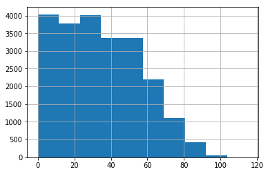

```python
df_noshow['Age'].hist();
```

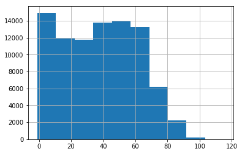

```python
df_show['Age'].hist();
```

Patients having medical background like HIpertension,Diabetes and Hadicap also have impact on percentage of no-show. Let observe the same with the formula below.

```python
percent_noshow_hipertension=count_Hipertension_1_n/count_Hipertension_1
percent_noshow_hipertension
```

```
0.17301958625751113
```

```python
percent_noshow_without_hipertension=count_Hipertension_0_n/count_Hipertension_0
percent_noshow_without_hipertension
```

```
0.20903680995424115
```

```python
percent_noshow_Diabetes=count_Diabetes_1_n/count_Diabetes_1
percent_noshow_Diabetes
```

```
0.18003273322422259
```

```python
percent_noshow_without_Diabetes=count_Diabetes_0_n/count_Diabetes_0
percent_noshow_without_Diabetes
```

```
0.20362824612025268
```

```python
percent_noshow_Handcap=count_Handcap_1_n/count_Handcap_1
percent_noshow_Handcap
```

```
0.1792360430950049
```

```python
percent_noshow_without_Handcap=count_Handcap_0_n/count_Handcap_0
percent_noshow_without_Handcap
```

```
0.20235302809227415
```

The percentage of no-show for patient suffering from Hipertension is 17% where as it is 21% for patients without Hipertension. The percentage of no-show for patient suffering from Diabetes is 18% where as it is 20% for patients without Diabetes. The percentage of no-show for patient who are Handicap is 18% where as it is 20% for patients who are not.

### What are the factors which have inverse impact on no-show?

```python
percent_noshow_scholarship=count_Scholarship_1_n*100/count_Scholarship_1
percent_noshow_scholarship
```

```
23.73630420771568
```

```python
percent_noshow_without_scholarship=count_Scholarship_0_n*100/count_Scholarship_0
percent_noshow_without_scholarship
```

```
19.807155900708366
```

The percentage no-show is more for patients who have scholarship than patients who do not have scholarship

```python
percent_noshow_smsreceived=sms_count_received_noshow*100/sms_count_received
percent_noshow_smsreceived
```

```
27.574544839637
```

```python
percent_noshow_sms_notreceived=sms_count_notreceived_noshow*100/sms_count_notreceived
percent_noshow_sms_notreceived
```

```
16.703311346525417
```

### What are the factors which do not have any impact on no-show?

Factor which do not have any impact on no-show is Gender and Alcoholism

```python
percent_female_noshow=female_noshow_count/female_total_count
percent_female_noshow
```

```
0.20314587973273943
```

```python
percent_male_noshow=male_noshow_count/male_total_count
percent_male_noshow
```

```
0.19967947889471915
```

We can see that percentage of no show for both the genders are equal.

## Conclusions

From the analysis, I observe that the factors Age, Hipertension, Diabetes and Hadicap have an impact on no-show. Patients with the average Age of 37 years have less no-shows that the patients with the average Age of 34. Similarly patients suffering from Hipertension, Diabetes or are Handicap have comparitively less amount of no-shows. Factors like Gender, Alcoholism have no impact on no-show. Patients having Scholarship or received SMS have more percentage of no-shows.